# Linear Regression: Dealing with Messy Data

Managerial Statistics - ECON 730

## R Packages Used In This Lecture

```r
if (!require("tidyverse")) install.packages("tidyverse")
suppressMessages(library(tidyverse))

#if (!require("Rmisc")) install.packages("Rmisc")
#suppressMessages(library(Rmisc))

if (!require("psych")) install.packages("psych")
suppressMessages(library(psych))

if (!require("car")) install.packages("car")
suppressMessages(library(car))
```

## Spurious Correlation

## Spurious Correlation

[interactive chart not shown]

## Conclution

- Spurious correlation occurs when the data coming from two unrelated variables is apparently correlated.
- You will find spurious correlation if you try many different variables.
- For this reason, it is important to do hard thinking about what variables are sensible to use in a regression before running it.

## Multicollinearity & Joint Significance

## Multicollinearity

- *Multicollinearity* is the term used to describe the correlation among the independent variables.
- A *multicollinearity problem* occurs when this correlation is high.

## The Hot Dog Case

- Your company: Dubuque.
- Ball Park: a leading brand.
- Ball Park may reduce hot dog price. *Problem:* Impact on Dubuque’s market share.
- Some argue that the impact will be small because Oscar Mayer is Dubuque’s leading competitor.

## The Hot Dog Case Background

- Ball Park produces two Hot Dogs.
  - Regular and All-beef Hot Dogs.
- Current Prices:
  - Ball Park 1.79 and 1.89 (regular and beef)
  - Dubuque 1.49
  - Oscar Mayer 1.69
- Ball Park new pricing:
  - Regular 1.45, All-beef 1.55

## The Question

What will happen to Dubuque’s market share if Dubuque does not respond to Ball Park’s new campaign?

## Load and Examen the Data

```r
hotdog <- read.csv("data/Hotdog.csv")
head(hotdog)
```

```
     MKTDUB pdub poscar pbpreg pbpbeef
1 0.0454565  149    169    169     180
2 0.0930145  149    199    189     205
3 0.0596656  189    199    189     205
4 0.0345966  189    199    189     201
5 0.0276536  189    169    159     166
6 0.0294224  189    199    189     196
```

## Linear Model

```r
hotdog.lm01 = lm(MKTDUB ~ pdub + poscar + pbpreg + pbpbeef, data=hotdog)
summary(hotdog.lm01)
```

```
Call:
lm(formula = MKTDUB ~ pdub + poscar + pbpreg + pbpbeef, data = hotdog)

Residuals:
      Min        1Q    Median        3Q       Max
-0.018182 -0.005925 -0.002253  0.004482  0.039256

Coefficients:
              Estimate Std. Error t value Pr(>|t|)
(Intercept)  4.046e-02  1.418e-02   2.853  0.00518 **
pdub        -7.615e-04  8.050e-05  -9.460 7.87e-16 ***
poscar       2.633e-04  8.423e-05   3.126  0.00228 **
pbpreg       3.938e-04  2.495e-04   1.578  0.11751
pbpbeef      5.750e-05  2.066e-04   0.278  0.78130
---
Signif. codes:  0 '***' 0.001 '**' 0.01 '*' 0.05 '.' 0.1 ' ' 1

Residual standard error: 0.01001 on 108 degrees of freedom
Multiple R-squared:  0.5261,    Adjusted R-squared:  0.5086
F-statistic: 29.98 on 4 and 108 DF,  p-value: < 2.2e-16
```

## Matrix Scater Plot

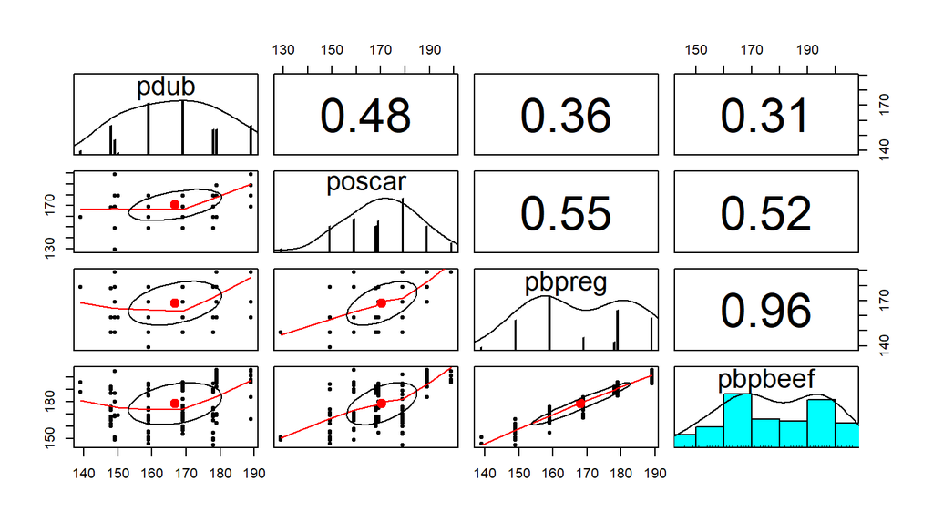

```r
pairs.panels(hotdog[,2:5])
```

## Scatter plot of pdpreg vs. pbpbeef

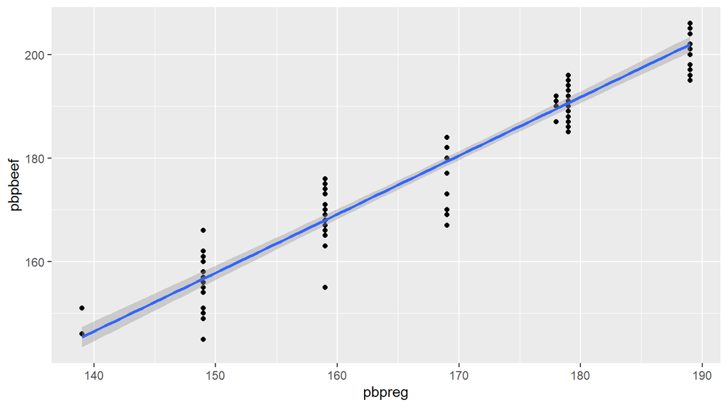

## Restricted model

```r
hotdog.lm02 = lm(MKTDUB ~ pdub + poscar + pbpbeef, data=hotdog)
summary(hotdog.lm02)
```

```
Call:
lm(formula = MKTDUB ~ pdub + poscar + pbpbeef, data = hotdog)

Residuals:
      Min        1Q    Median        3Q       Max
-0.018606 -0.005765 -0.001598  0.004916  0.038988

Coefficients:
              Estimate Std. Error t value Pr(>|t|)
(Intercept)  4.497e-02  1.398e-02   3.217  0.00171 **
pdub        -7.420e-04  8.008e-05  -9.266 2.02e-15 ***
poscar       2.823e-04  8.393e-05   3.364  0.00106 **
pbpbeef      3.669e-04  6.543e-05   5.608 1.57e-07 ***
---
Signif. codes:  0 '***' 0.001 '**' 0.01 '*' 0.05 '.' 0.1 ' ' 1

Residual standard error: 0.01008 on 109 degrees of freedom
Multiple R-squared:  0.5152,    Adjusted R-squared:  0.5019
F-statistic: 38.61 on 3 and 109 DF,  p-value: < 2.2e-16
```

## Joint signifance: the F-test

\[\begin{array}{l} {H_0}:{\beta _{pbpreg}} = {\beta _{pbpbeef}} = 0\\ {H_a}:{\beta _{pbpreg}} \ne 0\; \vee \;{\beta _{pbpbeef}} \ne 0 \end{array}\]

This F-test asks: Are they jointly significant?

## The F-Test

```r
# library(car)

linearHypothesis(hotdog.lm01, c("pbpreg","pbpbeef"))
```

```
Linear hypothesis test

Hypothesis:
pbpreg = 0
pbpbeef = 0

Model 1: restricted model
Model 2: MKTDUB ~ pdub + poscar + pbpreg + pbpbeef

  Res.Df      RSS Df Sum of Sq      F   Pr(>F)
1    110 0.014258
2    108 0.010816  2 0.0034416 17.182 3.32e-07 ***
---
Signif. codes:  0 '***' 0.001 '**' 0.01 '*' 0.05 '.' 0.1 ' ' 1
```

## How to Detect Multicollinearity

- The variance inflation factor is an indicator of a multicollinearity problem.
- Don’t bother
- Use `pairs.panels()`

## Conclution

## Bottom Line

- Regression must not be interpreted mechanically.
- Assumptions must be checked.
- Sometimes we may need to introduce non linear terms in our regression.
- Outliers and influential observations should not be modified or deleted unless there is measurement error or data entry error.
- Results driven by a few influential observations should be used with care.